# **R 유저들을 위한 단변량 시계열 예측 모형 Prophet 소개**

### 2.8 Diagnostics

Prophet에는 rolling window 기법을 이용한 교차검증(cross-validation)으로 모형 진단을 수행하는 기능도 포함되어있다. Prophet의 일반화 성능을 키우기 위해서는 $\tau$의 튜닝은 꼭 필요로 될 것이다. 교차검증의 수행을 위해서는 먼저 과거값과 미래값을 나누는 cutoff 포인트를 정해야 한다. 해당 지점까지 자료로 모형을 적합하고, 이후 원하는 만큼 예측을 수행하여 실제값과 비교해 예측 오차를 계산할 수 있다. 다음의 그림은 Peyton Manning 자료로 과거 5년 자료로 1년을 예측했다는 것을 나타낸다:

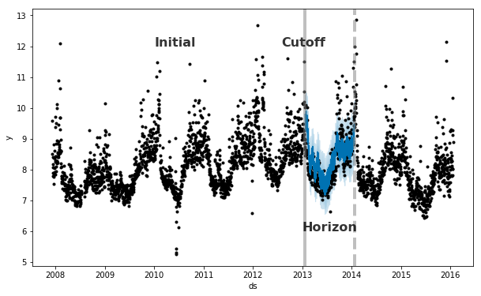

출처: facebook.github.io

교차검증 과정은 `cross_validation()`으로 정해진 cutoffs에 대해서 자동으로 수행된다. 우리는 훈련자료(training data) 이용할 크기, cutoffs 날짜 간 간격, 원하는 예측 길이(forecast horizon)을 `cross_validation()`의 인수 `initial`, `period`, `horizon` 각각에 명시해주면 된다. 그럼 cutoffs는 자동으로 결정이 된다. 기본 설정은 `horizon`을 명시해줄 경우, `initial`은 `horizon` 길이의 3배, `period`는 `horizon` 길이의 절반으로 설정된다.

`cross_validation()`의 결과는 실제값 `y`, out-of-sample의 예측값 `yhat`, 예측 날짜, cutoff 날짜에 관한 정보를 각 열로 갖는 데이터프레임으로 주어지며, 이 데이터프레임의 `yhat`과 `y`를 예측 오차의 계산에 사용한다.

다음의 예에서는 cutoffs 간격을 180일로 하고 약 2년을 훈련자료로 1년 예측을 수행해 교차검증을 한 것이다. Peyton Manning 자료에 대해 수행하였고, 해당 자료는 약 8년치 자료로 교차검증 수행결과 총 11개의 조각이 사용되었다.

```r
mod <- prophet(wp_log_peyton)
cv <- cross_validation(mod, initial = 730, period = 180, horizon = 365, units = 'days')
head(cv)
```

```
## # A tibble: 6 x 6
##       y ds                   yhat yhat_lower yhat_upper cutoff
##   <dbl> <dttm>              <dbl>      <dbl>      <dbl> <dttm>
## 1  8.24 2010-02-16 00:00:00  8.96       8.44       9.48 2010-02-15 00:00:00
## 2  8.01 2010-02-17 00:00:00  8.73       8.22       9.18 2010-02-15 00:00:00
## 3  8.05 2010-02-18 00:00:00  8.61       8.10       9.16 2010-02-15 00:00:00
## 4  7.93 2010-02-19 00:00:00  8.53       8.03       9.05 2010-02-15 00:00:00
## 5  7.75 2010-02-20 00:00:00  8.27       7.75       8.77 2010-02-15 00:00:00
## 6  7.87 2010-02-21 00:00:00  8.60       8.12       9.08 2010-02-15 00:00:00
```

```r
metrics <- performance_metrics(cv)
head(metrics)
```

```
##   horizon       mse      rmse       mae       mape  coverage
## 1 37 days 0.4952641 0.7037501 0.5057228 0.05860047 0.6703974
## 2 38 days 0.5010065 0.7078182 0.5106924 0.05917618 0.6690270
## 3 39 days 0.5231752 0.7233085 0.5167776 0.05977515 0.6687985
## 4 40 days 0.5304372 0.7283112 0.5196655 0.06008407 0.6738237
## 5 41 days 0.5379029 0.7334186 0.5206700 0.06016423 0.6813614
## 6 42 days 0.5417055 0.7360064 0.5210985 0.06018962 0.6866149
```

결과가 37일 후부터 제공되는 이유는, `performance_metrics()`의 `rolling_window`인수가 default로 10%가 설정되어 있어, 365일 후까지의 예측값의 10%인 36일은 각 window에 포함시켜버리기 때문이다. 만약, 모든 예측 시점에 대한 평가 측도를 확인하고 싶다면, `rolling_window = 0`로 설정하면 된다.:

```r
performance_metrics(cv, rolling_window = 0) %>%
  head
```

```
##   horizon       mse      rmse       mae       mape  coverage
## 1  1 days 0.9849037 0.9924232 0.6058303 0.06178287 0.6363636
## 2  2 days 0.4071570 0.6380886 0.5192203 0.05859105 0.5454545
## 3  3 days 0.4699532 0.6855313 0.6147977 0.07237406 0.3636364
## 4  4 days 0.4492416 0.6702549 0.5624650 0.06639940 0.3636364
## 5  5 days 0.5229501 0.7231529 0.6210860 0.07166728 0.3636364
## 6  6 days 0.5023884 0.7087936 0.6055858 0.06991706 0.5454545
```

앞서 예측값의 10%인 36일가량을 window에 포함시켜 37일 후 미래시점을 예측했던 것과 달리 어떤 예측값도 window에 포함시키지 않았으므로, 37일 후의 예측값에 대한 성능은 저하됐을 것이다.

```r
performance_metrics(cv, rolling_window = 0) %>%
  filter(horizon > 36) %>%
  head
```

```
##   horizon       mse      rmse       mae       mape  coverage
## 1 37 days 1.2881538 1.1349686 0.6783799 0.06936382 0.8181818
## 2 38 days 0.9300617 0.9643971 0.7462724 0.08116223 0.5454545
## 3 39 days 1.2378044 1.1125666 0.7828375 0.08652777 0.4545455
## 4 40 days 0.7232904 0.8504648 0.6955012 0.08083572 0.5454545
## 5 41 days 0.7528676 0.8676795 0.6254528 0.07169405 0.6363636
## 6 42 days 0.6511875 0.8069619 0.6295458 0.07179033 0.6363636
```

그리고, 원하는 평가측도로의 시각화 기능도 제공한다:

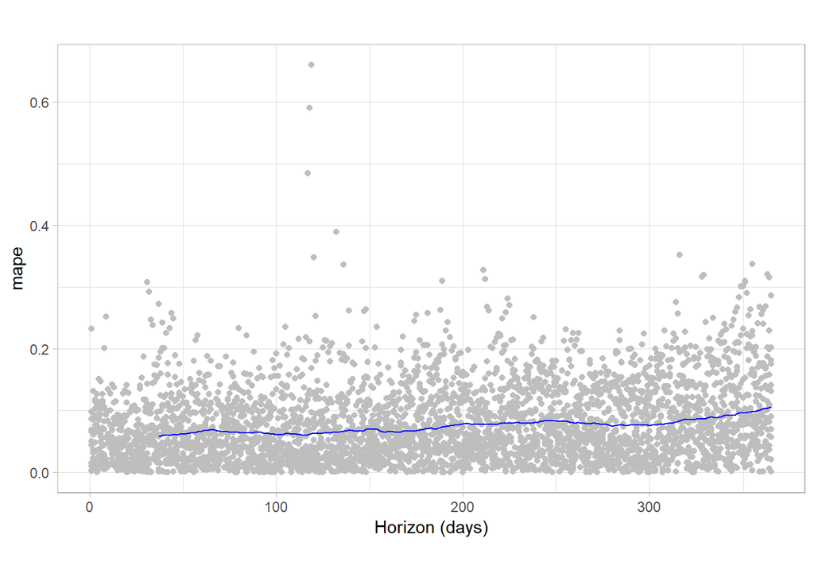

```r
plot_cross_validation_metric(cv, metric = 'mape')
```

그림의 파란색 선은 MAPE를 나타내며, 그에 따라 각 점은 APE(absolute percent error)를 나타낸다. 미래 시점의 한달정도까지는 약 5%의 MAPE 오차를 보이나, 1년 후 시점에 가까워질수록 약 11%까지 값이 증가하고 있다. 아울러, 해당 그림은 default로 `rolling_window = 0.1`이 설정되어 계산된 평가 측도로부터 그려진 것으로, `rolling_window`을 키울수록 더 많은 예측값은 window에 포함하게 되므로 파란색 선은 더 평활 될(smoother) 것이다. 그리고, 이러한 교차검증에서 주의할 점은 모형이 시계열의 모든 요소를 잘 추정할 수 있도록(특히, 계절성과 회귀자) 훈련자료의 길이(`initial`)를 충분히 길게 설정해야 한다는 것이다. 예컨대, 연별 계절성의 추정에는 최소 1년의 길이가 필요하고, 주별 계절성의 파악에는 최소 한 주가 포함되어야 한다.

#### 2.8.1 Hyperparameter tuning

그래서, R에서 Prophet 모형의 초모수들을 튜닝하고 최적의 모형을 선정하기 위해서는 병렬처리를 통한 교차검증을 수행할 수 있는 패키지의 도움을 받아야 할 듯하다. 이 부분에 대해서는 관련 자료를 좀 더 찾아보고 정리하여 완벽하게 글을 적어야겠다는 생각이 든다. 😭 마지막으로 Prophet 모형의 초모수 튜닝의 좋은 시작점이 될 수 있는 몇 가지 일반적인 권고사항을 적고 이번 챕터를 마친다:

- **Parameters that can be tuned**
  - `changepoint.prior.scale`($\tau$): $\tau$는 아마 Prophet의 적합에 가장 큰 영향을 미치는 모수에 해당 할 것이다. 추세의 유연성을 결정하며, 특히 추세 변화점에서 추세가 얼마나 변화될지에 관여한다. 값이 너무 작을경우, 추세는 과소적합(underfit) 될 것이고, 추세 변화로 모델링했어야 하는 분산이 잡음(noise) 항으로 처리 될 것이다. 반대로 값이 너무 클경우, 추세는 과적합 될 것이며, 아주 극단적으로 과적합된 추세로 모델링된 경우엔 추세가 연도별 계절성까지 잡아내는 상황에 놓이게 될 것이다. 해당 모수의 기본 설정은 0.05로 대부분의 시계열에 잘 작동하나, [0.001, 0.5]의 범위에서 조정될 수 있다. 그리고, 해당 모수는 2.2.1에서 언급했듯이 Lasso 회귀의 목적함수에 쓰이는 L1-regularization의 역할과 동일한데, 이러한 regularization penalty와 같은 모수의 튜닝에는 종종 로그 스케일이 쓰이곤 한다.
  - `seasonality.prior.scale`($\sigma^2$): $\sigma^2$는 계절성의 유연성을 조절한다. $\tau$와 비슷하게, 너무 큰 값은 계절성의 과적합, 너무 작은 값은 계절성의 과소적합을 야기할 것이다. $\sigma^2$의 기본값은 10으로, $\tau$와는 달리 큰 값으로 설정되어 있어 regularization은 기본적으로 적용되지 않는다. 그 이유는, 계절성의 경우 푸리에 차수 $N$을 고려함으로써 무한합이 아닌 절단된(truncated) 푸리에 급수로 모형화되기 때문이다. 그래서, 계절성의 과적합은 왠만해선 발생하지 않는다. $\sigma^2$의 합리적인 튜닝 범위는 [0.01, 10]으로, 만약 계절성의 크기는 매우 작게 추정하길 원한다면 0.01로 설정하면 될 것이다. 아울러, 해당 모수 또한 2.3.6에서 언급했듯이 Ridge penalty L2-regularization과 동일하므로 튜닝에 종종 로그 스케일이 쓰이곤 한다.
  - `holidays.prior.sacle`($\nu^2$): $\nu^2$은 휴일효과의 유연성을 조절한다. `seasonality.prior.scale`($\sigma^2$)과 유사하게, 기본값이 10으로 설정되어 있어 regularization은 기본적으로 적용되지 않는다. 그 이유는 보통 각 휴일효과의 날짜에는 많은 관측치들이 속하기 때문에, 휴일효과의 추정은 대체로 꽤 잘 이루어지기 때문이다. 아울러, $\nu^2$의 합리적 튜닝 범위도 [0.01, 10]에 해당하며, 이하 내용은 `seasonality.prior.scale`에서 언급한 것과 같다.
  - `seasonality.mode`: “additive” 또는 “multiplicative”로 설정이 가능하다. 기본설정은 “additive”이나, 대개 많은 business time series는 승법적 계절성을 갖는다. 이를 식별하는 가장 좋은 방법은 시계열의 시도표를 그려 시계열의 크기가 증가하면 계절 변동의 크기가 함께 증가하는 지를 확인하는 것이다. 만약 이게 불가능하다면, 튜닝을 수행할 수도 있다.
- **Maybe tune?**
  - `changepoint.range`: 추세 변화를 허용할 과거값의 비율을 조정한다. default는 80%로 시계열의 마지막 20%는 추세 변화에 고려되지 않을 것이다. 이는 시계열 끝 부분에서 추세 변화가 과적합되는 것을 피하기 위함이며, 마지막 20%를 고려하지 않는 것은 꽤 보수적인 설정이다. 다만, 해당 모수는 시계열의 길이가 아주 길지 않은 이상 튜닝하지 않는 것이 더 좋을 것이다. 시계열의 길이가 충분히 길다면, [0.8, 0.95]가 해당 모수의 합리적인 범위가 된다.
- **Parameters that would likely not be tuned**
  - `growth`: “linear”나 “logistic”으로 선택이 가능하다. 알려진 포화점과 해당 점으로의 성장이 있으면 로지스틱 성장 추세를 사용하고, 아니면 선형을 사용한다.
  - `changepoints`: 변화점의 위치를 명시하는 것으로, 기본 설정은 따로 없이 자료에 따라 자동으로 배치된다.
  - `n.changepoints`: 자동으로 설정되는 변화점의 수를 결정하는 인수로, default는 25개로 일반적인 시계열의 추세 변화를 충분히 포착할 수 있다. 그리고, 추세 변화를 잘 반영하기 위해 해당 옵션을 조정하는 것보다는 추세 변화에 대한 유연성을 조정하는 `changepoint.prior.scale`($\tau$)를 튜닝하는 것이 훨씬 더 효과적이다.
  - `yearly.seasonality`: [“auto”, “TRUE”, “FALSE”] 3가지 옵션을 선택할 수 있으며, default는 “auto”로 1년 이상 기록된 자료의 경우 자동으로 연별 계절성이 탐지될 것이다. 아울러, 자료가 1년 이상인 경우 해당 옵션은 on, off 해가며 모형을 튜닝하는것 보다는 연별 계절성을 탐지하는 채로 `seasonality.prior.scale`을 통해 계절성의 크기를 조정하는 것이 훨씬 더 좋을 것이다.
  - `weekly.seasonality`: `yearly.seasonality`와 동문
  - `daily.seasonality`: `yearly.seasonality`와 동문
  - `holidays`: 반영하고자하는 휴일효과 목록을 명시하는 인수에 해당한다. 휴일효과의 크기를 튜닝하고 싶다면 `holidays_prior_scale`를 이용하면 된다.
  - `mcmc_samples`: MCMC의 사용 여부는 주어진 시계열 자료의 길이나 계절성의 uncertainty의 중요성과 같은 요인에 의해 결정될 수 있다(see 2.5.2).
  - `interval.width`: Prophet 모형의 `predict()`는 각 요소에 대한 uncertainty intervals(`yhat_lower`, `yhat_upper`)을 제공해준다. 해당 구간은 사후예측분포(the posterior predictive distribution)의 분위수로 계산되고, `interval.width`는 어느 분위수를 사용할지를 명시한다. 기본적으로 80%의 예측 구간이 설정되어있으며, 만약 95% 구간을 구하고 싶다면 0.95로 설정하면된다. 해당 인수는 단지 원하는 구간의 넓이에 관여하는 것이지, `yhat`에 미치는 영향은 없기때문에 애초에 튜닝과는 관계가 없다.
  - `uncertainty.samples`: 앞서 uncertainty intervals은 사후예측분포를 기반으로 계산한다고 하였는데, 이 사후예측분포는 몬테카를로 방법(Monte Carlo sampling)로 추정된다. `uncertainty.samples`는 바로 이 몬테카를로 방법에서 표본의 숫자를 결정하는 역할을 하며, default를 1000으로 되어있다. 표본을 많이 뽑을수록 계산비용은 크지만 uncertainty interval의 분산(Monte Carlo error)은 작아질 것이다. `uncertainty.samples`도 `interval.width`와 같은 이유에서 튜닝할 필요가 없는 모수다. 그저 자신이 원하는대로 명시하면 된다.

## **3 Additional Topics**

적합한 Prophet 모형을 외부 파일로 저장하고, 필요할 때 불러와서 사용할 수 있다.

```r
saveRDS(mod, file = "model.RDS")
mod <- readRDS(file = "model.RDS")
```